# Problema 2 - Checkpoint 1

Carlos Interaminense

June 5, 2017

## Como saber se uma série tem temporadas regulares, a partir da avaliação dos usuários?

Para responder a pergunta deste post, usou-se a base de dados coletada do IMDB (www.imbd.com) sobre séries de TV e, para facilitar a visualização dos dados, foi considerado um subconjuto dessa base de dados com as seguintes séries: Sense8, The 100, Daredevil e Flash.

A base de dados tem variáveis que podem ajudar a responder a pergunta, são elas: Temporada, Episódios e Avaliação dos episódios, além das séries escolhidas, é claro.

Temporada, é uma variável que depende da série, ou seja, informa a temporada de um episódio e a quantidade de temporadas depende de série para série, como podemos observar no gráfico a seguir:

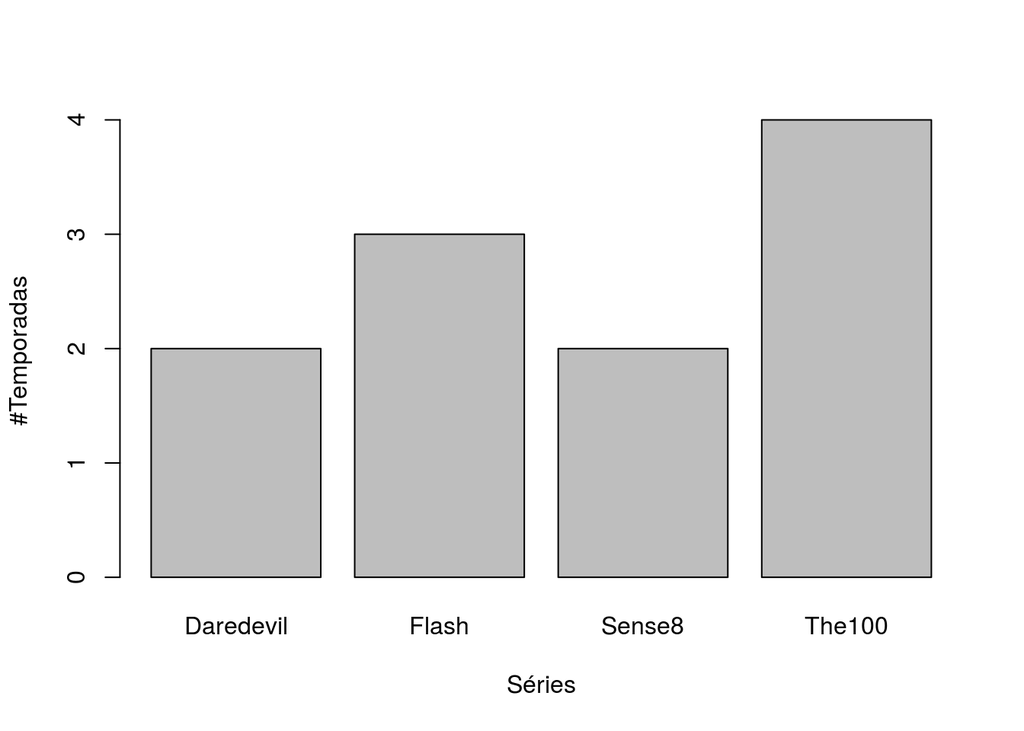

A mesma lógica da Temporada serve para a variável episódio, ou seja, a quantidade de episódios depende de uma temporada varia de série para série, como podemos observar no gráfico a seguir:

[interactive chart not shown]

A variável *Avalização* indica a classificação dos usuários do IMDB (para mais informações sobre User Rating, favor acessar este link). Essa variável deve ter valores entre 0 e 10, podemos observar se **todos** os valores estão nessa faixa de valor, podemos verificar o seguinte histograma:

[interactive chart not shown]

Agora que temos uma ideia geral do que cada variável representa, podemos analisar os dados e perceber qual a série que tem as temporadas mais regulares. *Lembrando que estamos considerando apenas as quatro séries informadas no início deste post*.

O gráfico a seguir tem um *boxplot* para cada temporada de cada série, a partir das avaliações dos usuários. É importante saber que, quanto mais a distância inter quartil (IQR) for maior, mais irregular essa temporada será.

[interactive chart not shown]

Em que: Temporada é a temporada da série e Avalização é a média das avaliações dos usuários para um episódio de uma série, em que um episódio é representado por cada “ponto” do gráfico.

Podemos observar que a terceira temporada de The100 possui a temporada mais irregular de todas as temporadas de todas as séries. Porém, **a série com temporadas mais irregular é Flash**, pois todas as suas teporadas têm IQR maior que as demais temporadas das outras séries, com exceção da terceira temporada de The100.